# Financial Contribution to Presidential Campaigns in California

# Summary

# The Data Structure

The dataset records the presidential contribution from individuals in California in presiential election. It’s a tabulor dataset contains 548166 observations of 18 variables. Each observation is a transition that contributor made to support a specific candidate. Therefore, each transition contains three parts of information: - Contributors, including its name, zipcode, city, employer, occupation, state; - Candidates, including candidate’s name, committee ID and candidate ID; - Transition details, including receipt date, receipt amount, receipt description, memo code, memo, from_type, transition ID, amount, file number and election type. Exploring this rich dataset helps us understand the political landscape in California presidential election.

```
## 'data.frame':    548166 obs. of  18 variables:
##  $ cmte_id          : Factor w/ 25 levels "C00458844","C00500587",..: 7 7 7 7 7 7 7 7 7 7 ...
##  $ cand_id          : Factor w/ 25 levels "cand_id","P00003392",..: 13 13 13 13 13 13 13 13 13 13 ...
##  $ cand_name        : Factor w/ 25 levels "Bush, Jeb","cand_nm",..: 20 20 20 20 20 20 20 20 20 20 ...
##  $ contrb_nm        : Factor w/ 100017 levels "_BOOTH, ELAINE S.",..: 4881 12668 12678 12681 12694 899 5959 13198 13198 13198 ...
##  $ contrb_city      : Factor w/ 1464 levels "","*MORENO VALLEY",..: 1138 1175 721 570 1184 249 1072 1179 1179 1179 ...
##  $ contrb_st        : Factor w/ 2 levels "CA","contbr_st": 1 1 1 1 1 1 1 1 1 1 ...
##  $ contrb_zip       : Factor w/ 85151 levels "","00000","000090272",..: 53916 41095 1547 33840 11562 23445 66550 71648 71648 71648 ...
##  $ contrb_employer  : Factor w/ 34055 levels ""," APPLE INC.",..: 4793 18837 26433 4109 11817 9836 20673 24075 24075 24075 ...
##  $ contrb_occupation: Factor w/ 15689 levels ""," REAL ESTATE BROKER",..: 11518 1989 15008 4683 11277 4683 9115 11855 11855 11855 ...
##  $ contb_receipt_amt: Factor w/ 5870 levels "-.44","-.76",..: 599 599 3760 2425 3675 3984 4925 4415 1650 4415 ...
##  $ contb_receipt_DT : Factor w/ 488 levels "01-APR-15","01-APR-16",..: 452 452 452 452 452 452 452 452 452 452 ...
##  $ receipt_desc     : Factor w/ 66 levels "","* EARMARKED CONTRIBUTION: SEE BELOW REATTRIBUTION/REFUND PENDING",..: 1 1 1 1 1 1 1 1 1 1 ...
##  $ memo_cd          : Factor w/ 3 levels "","memo_cd","X": 1 1 1 1 1 1 1 1 1 1 ...
##  $ memo_text        : Factor w/ 250 levels "","*","* EARMARKED CONTRIBUTION: SEE BELOW",..: 3 3 3 3 1 3 3 3 3 3 ...
##  $ from_tp          : Factor w/ 4 levels "form_tp","SA17A",..: 2 2 2 2 2 2 2 2 2 2 ...
##  $ file_num         : Factor w/ 129 levels "1003942","1004025",..: 64 64 64 64 64 64 64 64 64 64 ...
##  $ tran_id          : Factor w/ 545830 levels "A000771210424405B8CF",..: 353073 352207 347385 351166 323101 352521 348822 349557 349644 349911 ...
##  $ election_tp      : Factor w/ 5 levels "","election_tp",..: 4 4 4 4 4 4 4 4 4 4 ...
```

# Univariate Analysis

### Main feature of interests

- *Univariate*. The main feature of interest in the dataset is to understand the popularity of candidates in California, and the distribution of supports in geography, occupation, and amounts of donations.
- *Bivariate and Multivariate*. It is also possible to uncover support pattern, for example, relationship between type of supporters and candidates by location or by occupation.

### Key variables

- The key variables are transaction amount, candidate names, contributors’ location by city or zipcode and occupation.
- Other features such as the party of candidates, date of the donation and the category of contribution by amount might also be helpful.

### Tidy and Clean the Data

Three changes are made to tidy and clean the data

- Changed the format of `contb_receipt_DT` from factor to date.
- Change the format of `contb_receipt_amt` from factor to character then to numeric. I notice there are some negative values, so in the analysis we d better only use the positive value.
- Extract the first five digits to make them consistent using stringr, since the zip code data is also inconsistent, some are nine digits and some are five.

### New Variables

Two new variables are created.

- I create a new variable called ‘party’ to help understand which party gain more popularity in California.
- I also create a variable called ‘contribution_category’ which includes five levels: negative, 0-50, 51-200, 201-1000, and 1000+.

# Univariate Plots Section

### Clean and Create New Variables

#### Creating new variable ‘party’

Since using for loop function to calculate the new field is too slow, so I subset the dataset into three, then add party variable to each of them and rbind them.

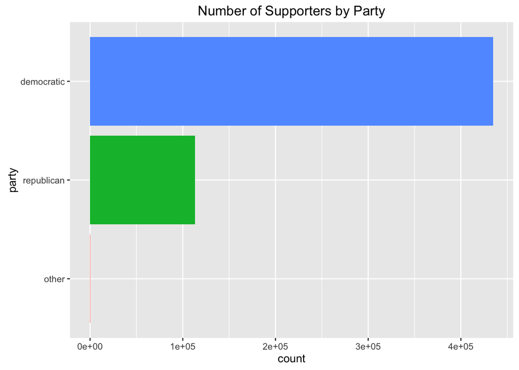

#### Tidy the variable of contribution amount

Step 1.Turning it from factor to numeric

```
##      Min.   1st Qu.    Median      Mean   3rd Qu.      Max.
## -10000.00     15.00     27.44    135.20    100.00  10800.00
```

Step 2. Plot the contribution amount by distribution

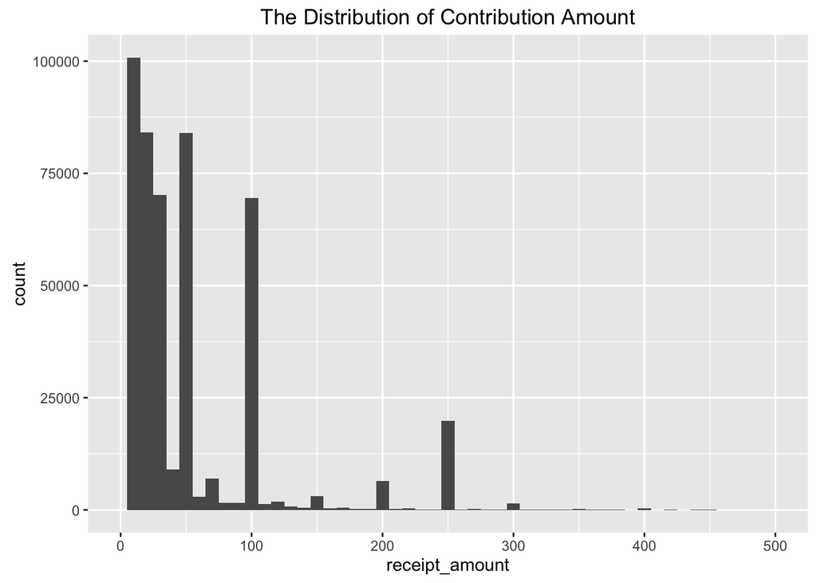

#### Create a new variable called ‘contrb_category’

This variable categorizes the contribution amount to five categories: `negative, 0-50, 51-200, 201-1000, more_than_1000`. We plot the number of contribution by category and find most contributions are under 50USD.

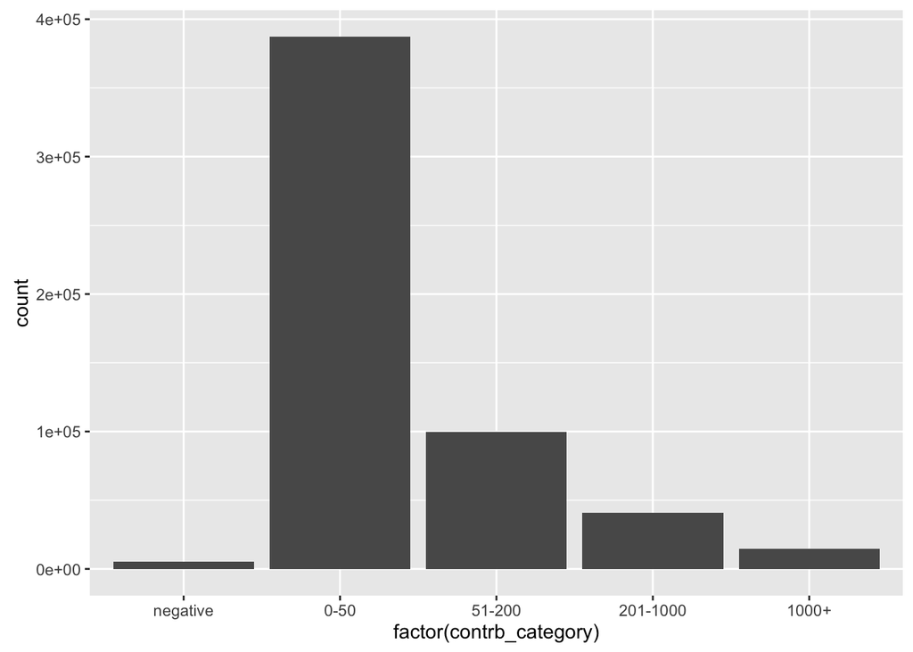

```r
ca_new$contrb_category<-cut(ca_new$receipt_amount,breaks=c(-100001 ,0, 50, 200, 1000, 11000))
ca_new$contrb_category<-revalue(ca_new$contrb_category, c("(-1e+05,0]"="negative", "(0,50]"="0-50","(50,200]"="51-200","(200,1e+03]"="201-1000","(1e+03,1.1e+04]"='1000+'))
ggplot(aes(x=factor(contrb_category)), data=ca_new)+geom_bar()
```

#### Clean the contrb_zip variable

Update the zipcode by only including the first five digits and find the top 10 neighborhoods by count.

```
##
## 94110 94114 94611 90046 94117 95060 94109 90049 90069 90405
##  4506  3893  3234  3089  3031  2738  2349  2328  2325  2301
```

### Ditribution of Key Variables

#### Candidates and Number of Supports (Count)

The top 10 candidates by popularity (Number of Supports)

```
##
##          Sanders, Bernard   Clinton, Hillary Rodham
##                    309233                    125141
## Cruz, Rafael Edward 'Ted'       Carson, Benjamin S.
##                     53207                     27337
##              Rubio, Marco            Fiorina, Carly
##                     13755                      4696
##                Paul, Rand                 Bush, Jeb
##                      4255                      3109
##           Kasich, John R.          Trump, Donald J.
##                      2857                      1370
```

#### Number of Supports(Count) by City

Top 10 Cities by Number of Supports

```
##
##   LOS ANGELES SAN FRANCISCO     SAN DIEGO       OAKLAND      SAN JOSE
##         40072         37034         19257         13507         13246
##      BERKELEY    SACRAMENTO  SANTA MONICA    LONG BEACH    SANTA CRUZ
##         10469          9207          5819          5758          5448
## SANTA BARBARA    SANTA ROSA      PASADENA     PALO ALTO        FRESNO
##          5404          5311          4862          4727          3920
##  WALNUT CREEK        IRVINE   BAKERSFIELD         DAVIS     SUNNYVALE
##          3521          3392          3119          3079          3008
```

#### Number of Supports(Count) by Occupation

Top 10 Occupations by Number of Supports

```
##
##          NOT EMPLOYED               RETIRED              ATTORNEY
##                 83733                 81385                 12342
##               TEACHER              ENGINEER     SOFTWARE ENGINEER
##                 12126                  8500                  8106
##             HOMEMAKER             PHYSICIAN INFORMATION REQUESTED
##                  6642                  6505                  5403
##            CONSULTANT
##                  5237
```

#### Number of Supports(Count) overtime

Here we examine the supports made after 2015

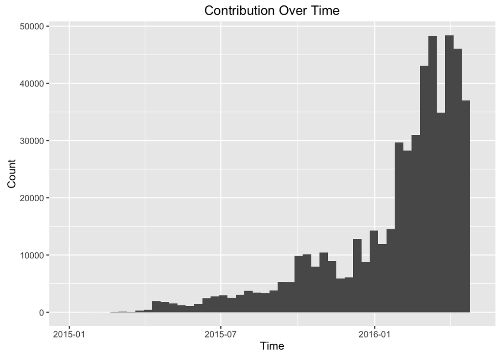

```
##         Min.      1st Qu.       Median         Mean      3rd Qu.
## "2013-11-05" "2015-12-31" "2016-02-29" "2016-02-01" "2016-03-31"
##         Max.
## "2016-04-30"
```

#### Number of Supports(Count) by Employer

```
##  [1] NA NA NA NA NA NA NA NA NA NA
```

# Bivariate Plots Section

### Total Contribution by Candidate

Who are the 10 most popular candidates? How much contribution do they received?

We created a new table on the candidate’s donation received called `receipt_by_candidate`

[figure not shown]

[figure not shown]

### Total contribution and contribution distribution by party

We plot the count of support and the distribution of contribution amount by party.  
The average donoation to the democratic party is far less than that made to republican party.

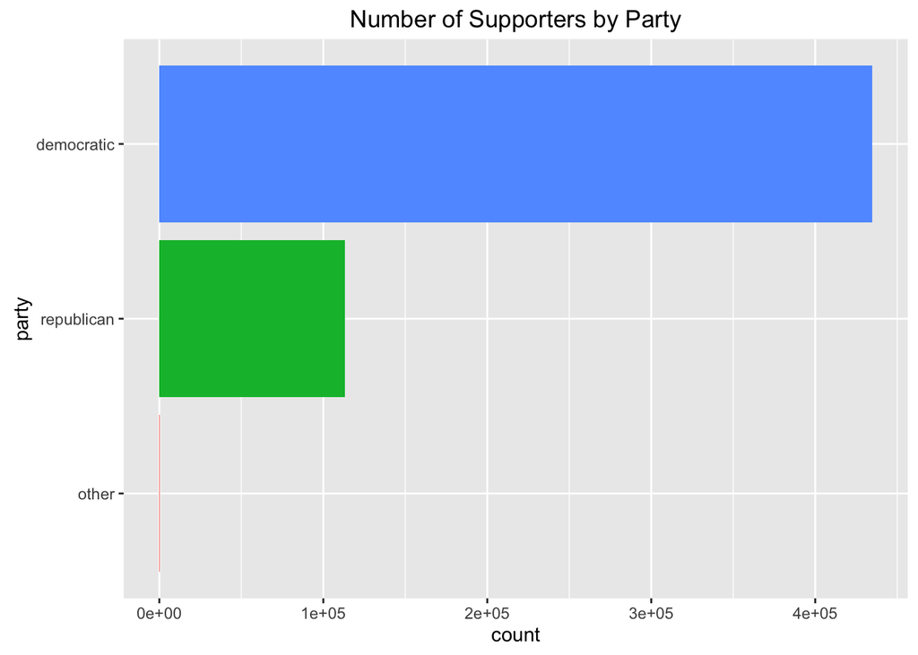

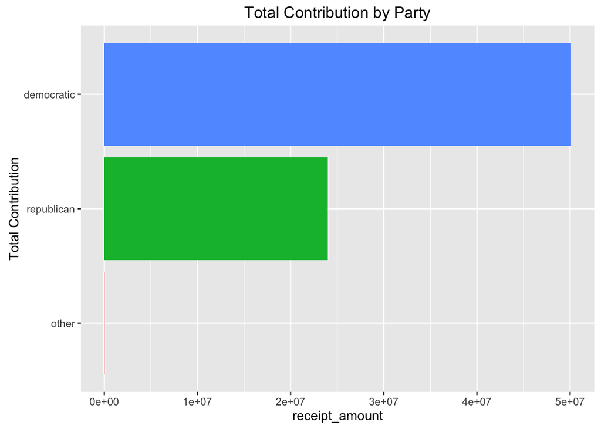

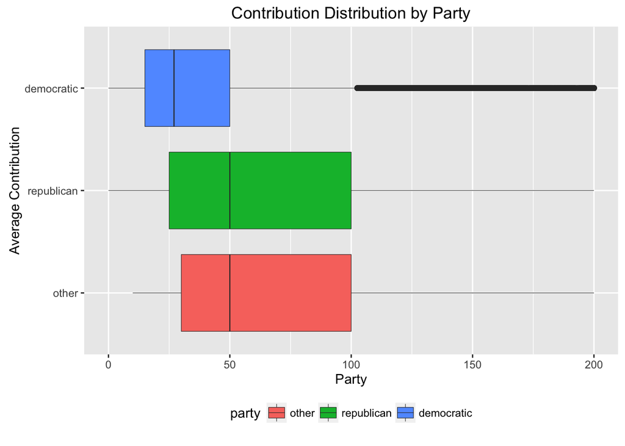

### Total contribution and contribution distribution by candidate When you plot the donation distribution by candidates, you get the similar finding, the democratic candidates receive many contributions but the amount are relatively small.

[figure not shown]

### Top Contributions by City

- Top ten cities by total contribution We first select the top 10 cities where the number of transactions are over 100 Then we plot the total contribution by city of the top 10
- LA and San Francisco are top cities that contribute the most donation

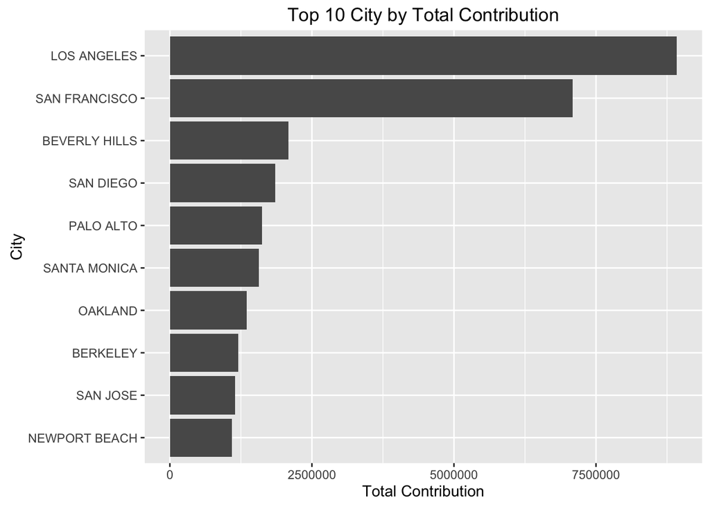

- The Top 10 Cities by Average Contribution

In response to question of “Where do the rich donors live?”. We look into the cities having highest average contribution and also with over 100 transactions. We found there is limited overlap between top cities with total contributions and rich cities with high average contribution. Rich communities did not dominate CA presidential contribution.

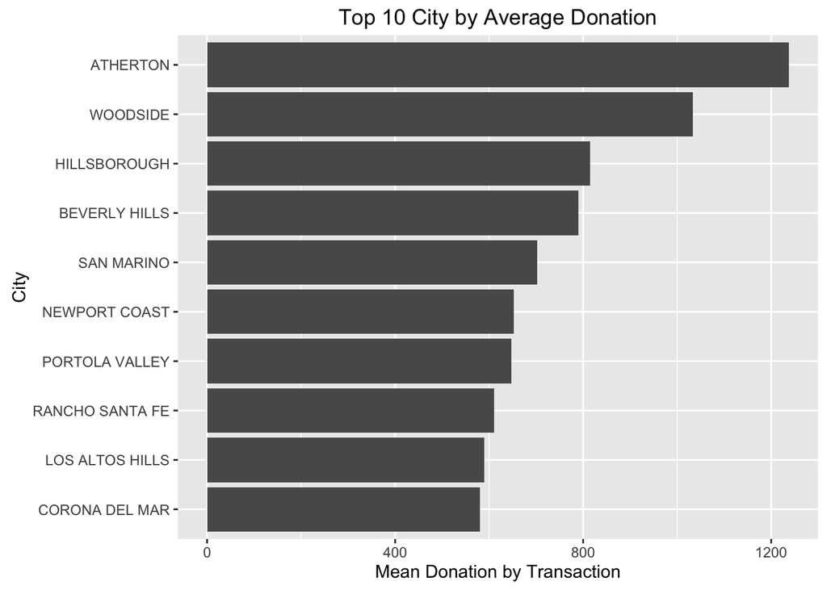

### Total Contribution by Occupation

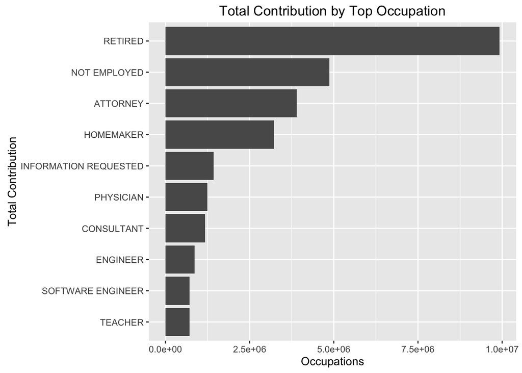

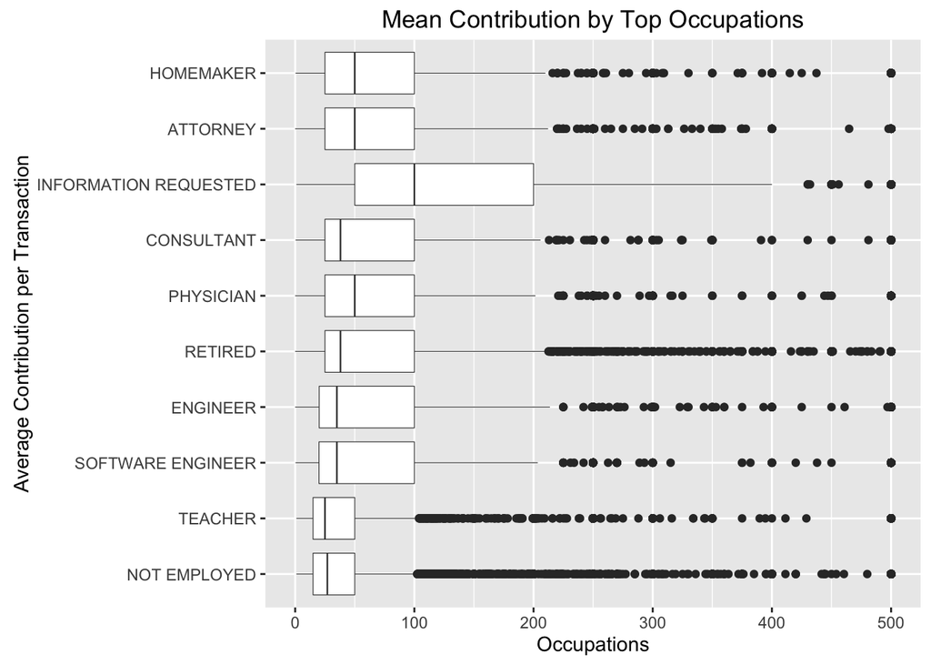

### Total Contribution by Zipcode

The top ten neighborhood by total contribution

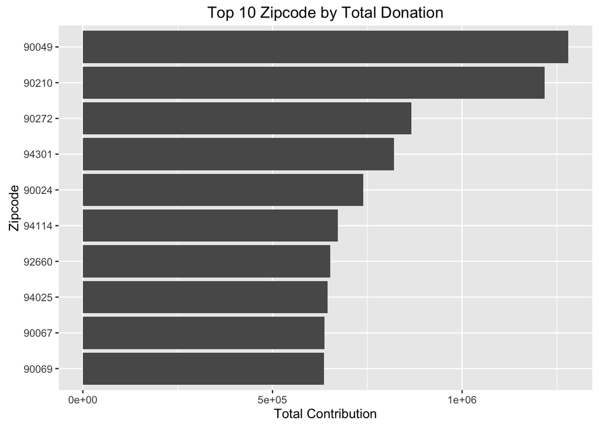

### Contribution count and total overtime by party

- The democratic dominates the number of contribtion, especially when it is in 2016.
- In terms of total amount, in 2015, the contribution is similar between two parties, but after 2016, domocratic has significant edge. This might be caused by unexpected raised popularity of Donald Trump and drop off of other republican candidates.

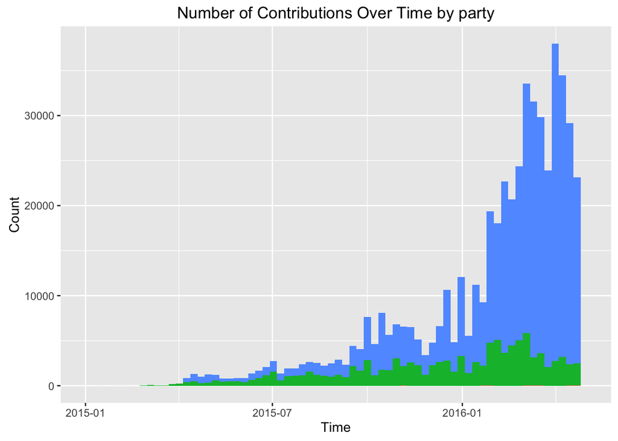

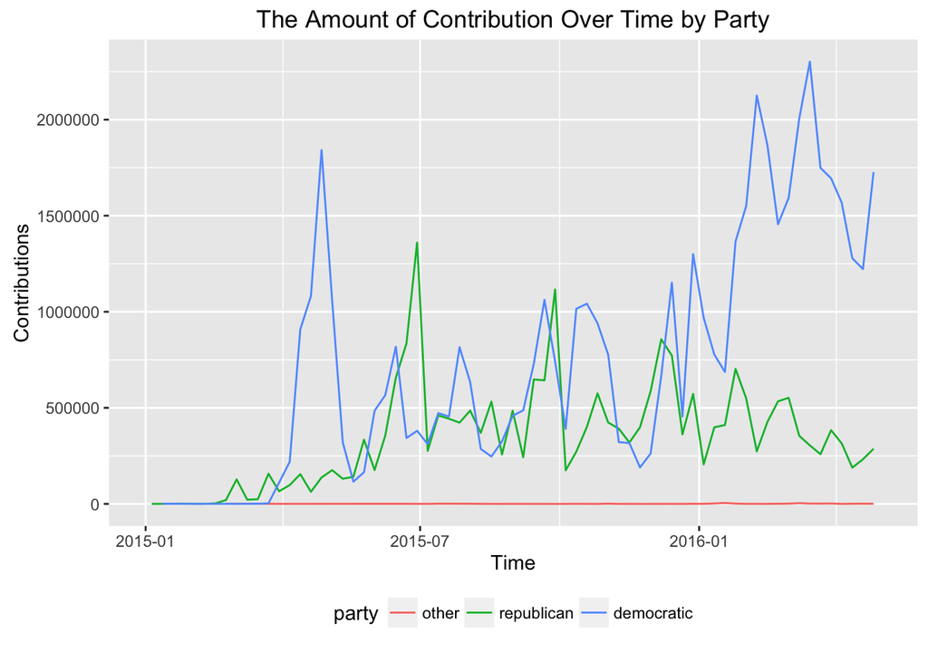

# Bivariate Analysis

### 1. Significant popularity of Democratic Candidates

Democratic supportors dominate California, no matter in terms of the amount of donation or number of supports. However, the number of supports and the total fund received by candidates is not necessarily positive related in California.

### 2. Bernard and Hillary

More than half of transaction support Sanders, but Clinton raise the most contributions, twice the Sanders. Mean donation by individual varies by candidate a lot.

### 3. Key supportive forces by occupation.

Supportors by occupation is interesting. The retired comprises the largest supportive force. The not-employed has the second largest, which is unexpected. Homemaker also have very strong power in political landscape in California as they contribute the forth largest amount of money to candidates with very high average.It would be interesting to see who they support

### 4. Number of Contributions over time by party

Democratic candidates receive incresed number of contributions overtime, while support to republican candidate seems to decrease after 2016. This might due to the drop off of many republican candidates and unexpect raise of Trump.

# Multivariate Plots Section

### Total Contribution by Candiates and Contribution Category

As Domocratic party has significant popularity in California and Hillary and Bernard are two most popular candidate, it might be interesting to create a new variable called cand_name2 include Hillary, Bernard and other republican candidates.

As shown in the following plot, Bernard received support mostly from small contributions.While Hillary seem to be popular accross different group. She also received lots of contributions which are over 1000USD.

```r
candidate_support_pattern<-ggplot(aes(x=reorder(cand_name2, receipt_amount, FUN=sum), y=receipt_amount, fill=contrb_category), data=subset(newdata, receipt_amount>0))+geom_bar(stat='summary', fun.y=sum)+scale_fill_brewer(type='seq')+ggtitle('Total Contribution by Candidate/Party Colored by Contribution Amount Category')+ylab('Total Contribution')+xlab('Candidate/Party Names')+coord_flip()+scale_fill_discrete(name="")+scale_fill_brewer(type='seq')+theme(legend.position='bottom')
```

```
## which will replace the existing scale.
## which will replace the existing scale.
```

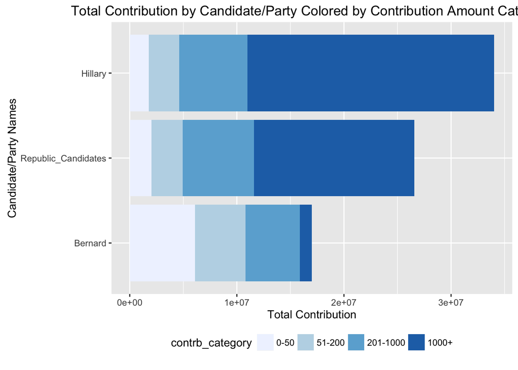

```r
plot(candidate_support_pattern)
```

### Support Pattern by Occupation

Retired and homemaker more likely to support republic candidates. They are also more likely to support Hillary than Bernard. Not-employed only support democratic candidates, and most of them support Bernard.

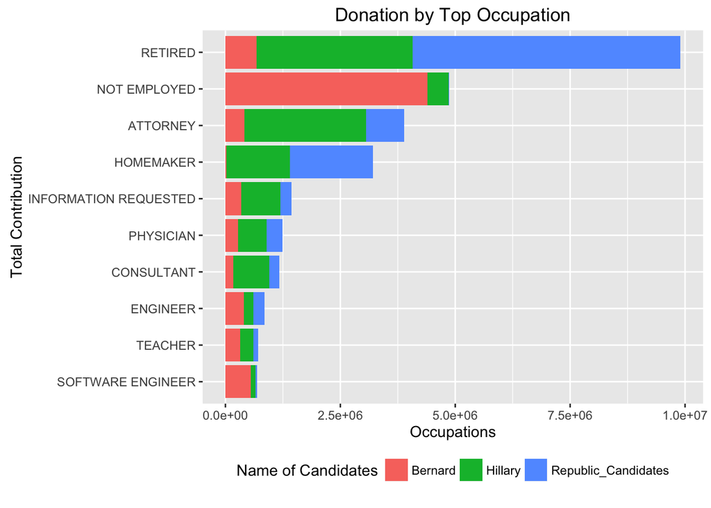

### Support pattern in top and bottom cities in terms of contribution avereage

Both high and low communities have diverse political voices. However, high-income communities are more likely to support republican candidates or Hillary. Sanders has larger support in the poor community.

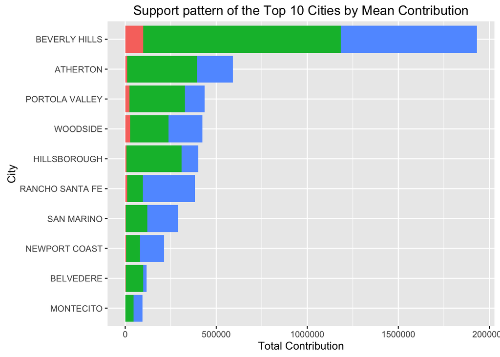

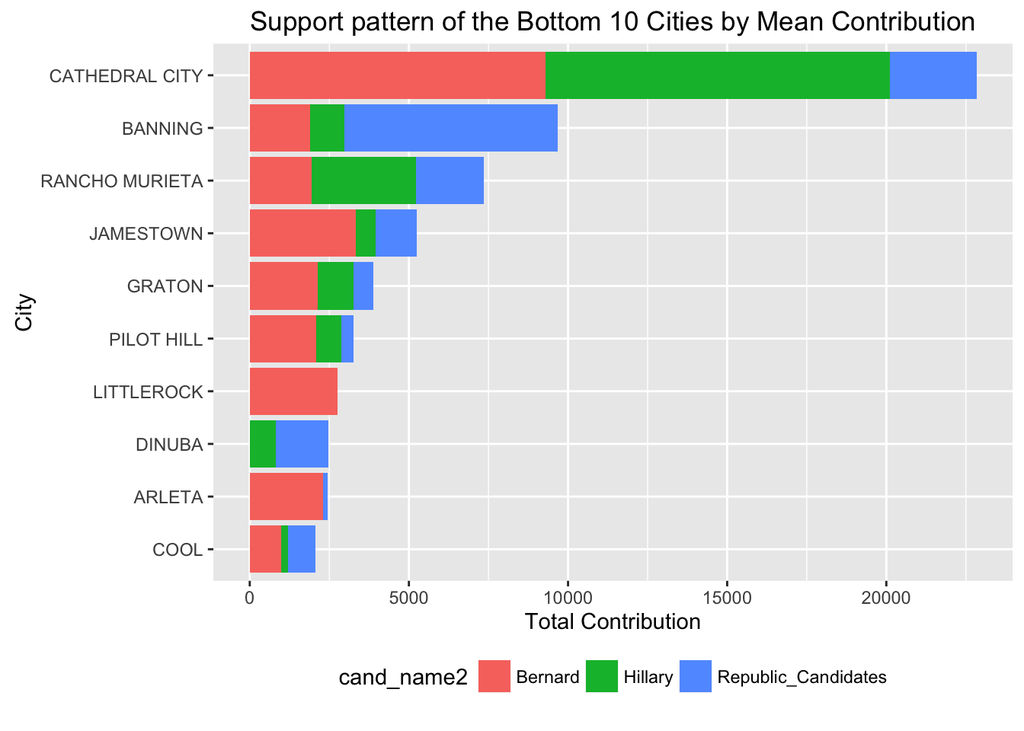

# Multivariate Analysis

### Candidates’ Popularity varies by geography and occupation

Mulivariate Analysis confirm again that candidates seems to have different popularity in different income groups.

- The affluent are more likely to support the Republican Candiates, and when they support Domocratic Candidate, they are more likely to support Hillary. This is reflected in support parttern by geography.
- Retired, Homemakers and Attorneys are more likely to support Republican Candidates or Hillary, while unemployed are more likely to support Bernard.

### Classification Model

it is also possible to contruct a classification model (using logistic regression, ramdon forest, gradient boosting, svm, or netro nework) to predict the candidate based on the amount of contribution, the zipcode, and their occupation. I did not try any model here, but would be interested in exploring these options later.

# Key Plots and Summary

### 1. Candidates by Popularity

[figure not shown]

[figure not shown]

### 2. Support pattern by Candidate

The affluent are more likely to support the Republican Candiates, and when they support Domocratic Candidate, they are more likely to support Hillary. Bernard gain supports mostly from small contributions. The support pattern by cities with different levels of average contribution support this finding as well.

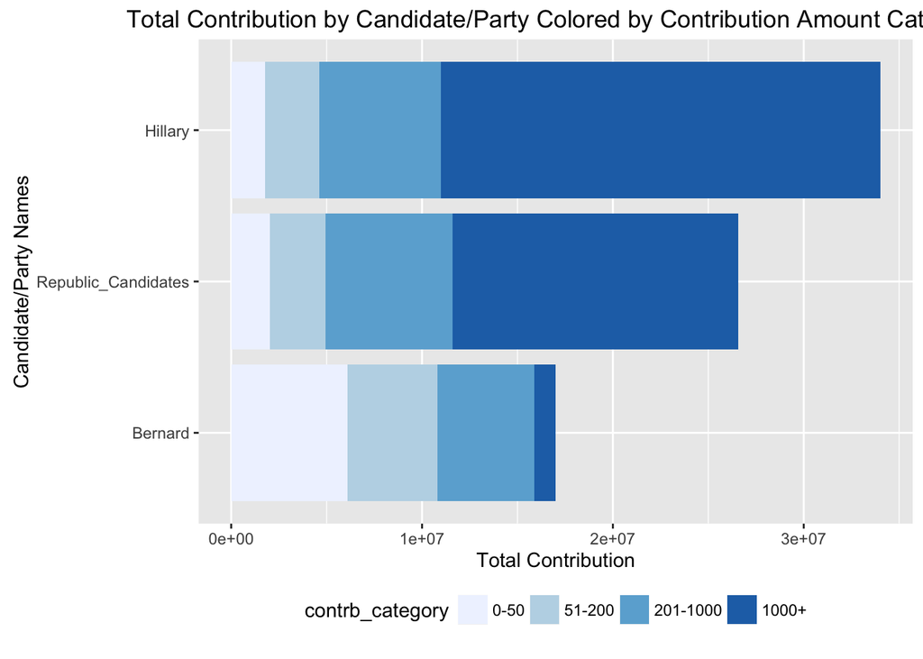

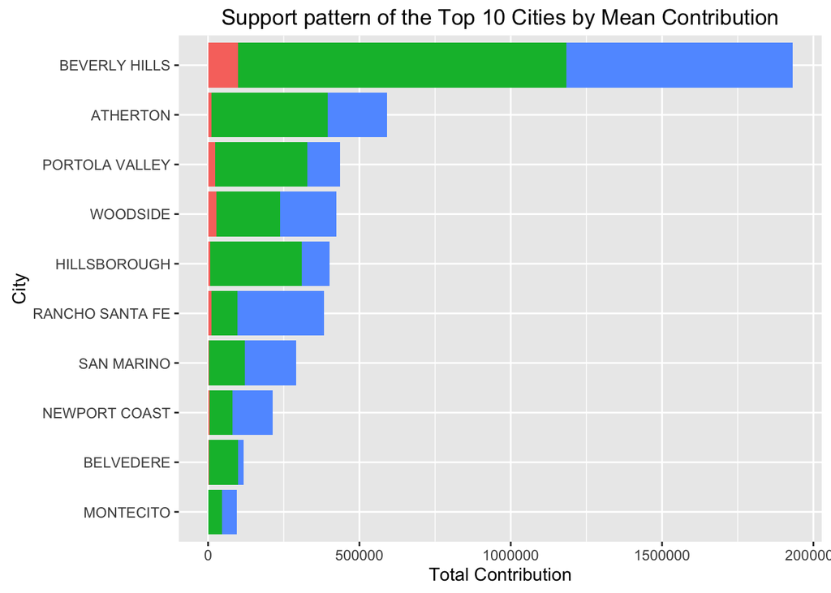

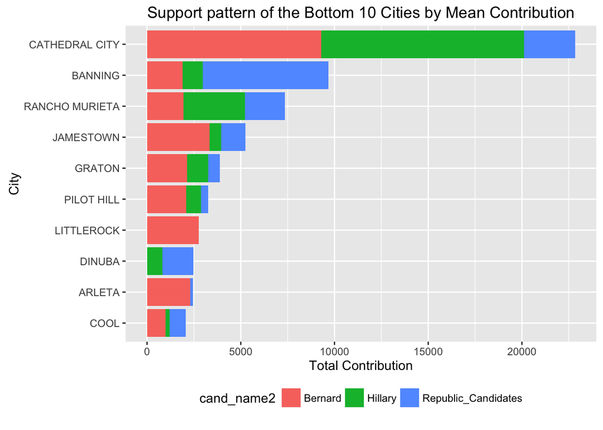

### 3.Support Pattern by Occupation

Support pattern varies by occupation.The retired, Homemakers and Attorneys are more likely to support Republican Candidates or Hillary, while unemployed are more likely to support Bernard.

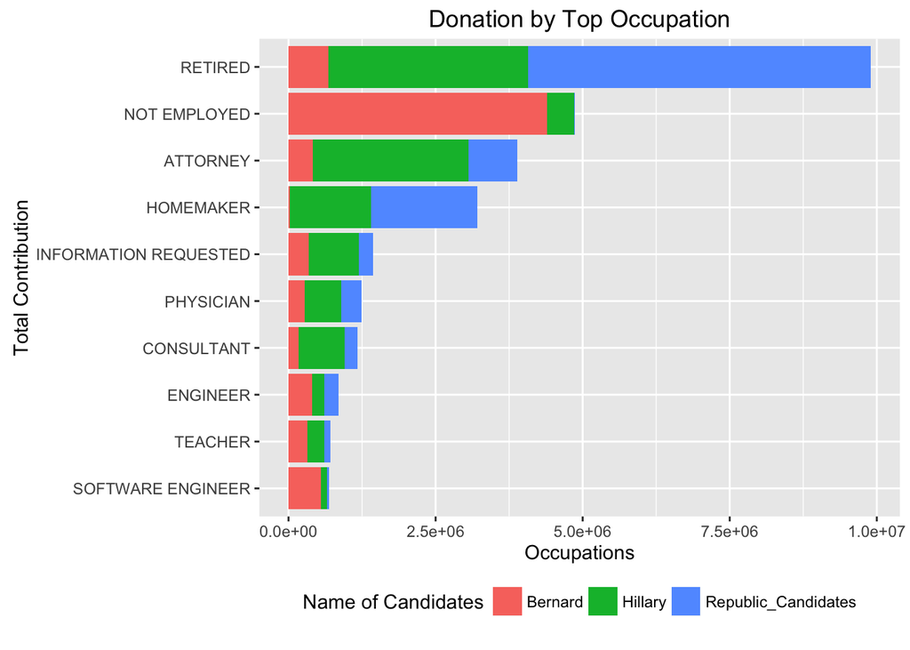

# Reflection

### Summary

Further examining the support pattern by candidate in democratic party we found Hillary received support from high-income or medium-high income constituents.This is confirmed by the geographic analysis, occupational analysis and also the contribution categorical analysis. In other words, candidate supports are related to income level, zipcode, occupation.

### Future Works

As California is known to be a democratic state for a long time. It would be interesting to compare the pattern presidential contribution to national average. On the other hand, it is also possible to contruct a classification model to predict the candidate based on the amount of contribution, the zipcode, and their occupation.